# Cookbook for trans-omics analysis in R

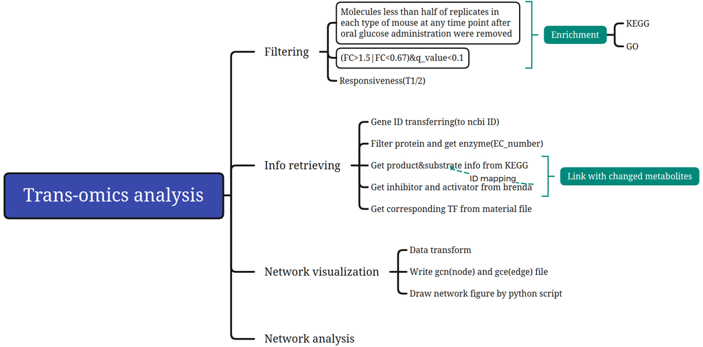

# Data preparing

- Since the raw data is in metalab format, using matlab function`writematrix(A,filename)` to convert it into csv file.
- Add col and row name based on given label in matlab file.

## 1. Import omics data

```r
data_trans = read_csv("yourdata") #change parameter based on your requirements
data_metab=read_csv("yourdata") # imported data is in tibble format
data=base::as.data.frame(data)#If you do not like tibble format dataset
View(data_trans)
View(data_metab)
```

## 2. Responsive molecules identification

Remove those are absent in more than half of replicates molecules

```r
trans_sample_num=list(1:11,12:14,15:17,18:20,21:23,24:35,36:38,39:41,42:44,45:47)
metab_sample_num=list(1:5,6:10,11:15,16:20,21:25,26:30,31:35,36:40,41:45,46:50)
data_trans[is.na(data_trans)]=0 #replace nan data with 0
data_metab[is.na(data_metab)]=0

missing_filter=function(df,group){
  output=c()
  for (i in 1:dim(df)[1]) {
    for (j in group) {
      if (median(as.matrix(df[i,j]))==0) {
        output=c(output,row.names(df)[i])
        break
      }
    }
  }
  return(unique(output))
}

del_miss_trans=missing_filter(data_trans,trans_sample_num)
#del_miss_metab=missing_filter(data_metab,metab_sample_num)
data_trans_=data_trans[!(row.names(data_trans)%in%del_miss_trans),]
#data_metab_=data_metab[!(row.names(data_metab)%in%del_miss_metab),]
```

Calculate FC, p value and p-adjust value

```r
#An example,this function can be written better...
calculator=function(df,group_name,con_group,exp_group){
  p_value=c()
  FC=(rowSums(df[,exp_group[[1]]])/length(exp_group[[1]]))/(rowSums(df[,con_group[[1]]])/length(con_group[[1]]))
  for (i in 1:dim(df)[1]) {
  p_value=c(p_value,t.test(df[i,exp_group[[1]]],df[i,con_group[[1]]])$p.value)
  }
  p_value_adjust=p.adjust(p_value,method="BH")
  colname=c(base::paste('FC_',group_name,sep=''),base::paste('p_',group_name,sep=''),base::paste('p_',group_name,'_adjust',sep=''))
  df[,c(colname[1])]=FC
  df[,c(colname[2])]=p_value
  df[,c(colname[3])]=p_value_adjust
  df#return new dataframe
}

#group_name=c(c('wt20','wt60','wt120','wt240'),c('ob20','ob60','ob120','ob240'))
#group_position=c(2:5,7:10)
data_trans_=calculator(data_trans_,'wt20',trans_sample_num[1],trans_sample_num[2])
```

FC>1.5 or <0.67 and p-adjust value <0.1

```r
trans_data_position=list(48:50)#list(48:50,51:53,54:56,57:59)
FC_filter=function(df,group){
  output=c()
  for (i in 1:dim(df)[1]) {
    for (j in group) {
      if ((df[i,j[1]]>1.5|df[i,j[1]]<0.67)&df[i,j[3]]<0.1) {
        output=c(output,row.names(df)[i])
        break
      }
    }
  }
  unique(output)
}
response_trans=FC_filter(data_trans_,trans_data_position)#response transcripts
```

# Information retrieving

## 1. ID conversion

From ensemble to gene ID (NCBI database).

```r
library(biomaRt)
ensembl=useEnsembl(biomart = 'genes',dataset = 'mmusculus_gene_ensembl',mirror = 'asia')
trans_info=getBM(attributes = c('ensembl_gene_id','entrezgene_id', 'transcript_length'),
      values = response_trans,
      filters = 'ensembl_gene_id',
      mart = ensembl)
```

Remove duplicated and NA data.

```r
#Clean dirty retrieve results(base on length)
trans_info=trans_info%>%drop_na()
trans_info=trans_info[order(trans_info$transcript_length,decreasing = TRUE),]
trans_info=trans_info%>%distinct(entrezgene_id,.keep_all = TRUE)
length(unique(trans_info$ensembl_gene_id))#There are some transcripts having multiple gene_ID retrieve results, but can be partially filtered based on EC_number retrieve.
trans_info[duplicated(trans_info$ensembl_gene_id),]
```

## 2. Retrieve information from various database

Most of these package are downloaded from bioconductor. Please read manual guidance or toy example if you want:)

### 1. Retrieve information from KEGG

#### Get KEGG_id

Basically the gene_id = kegg_id, but there are still some exceptions…

```r
library(KEGGREST)
#Decrease 403 possibility...
testit =function(x)
{
    p1= proc.time()
    Sys.sleep(x)
    proc.time() - p1 # The cpu usage should be negligible
}
for (i in 1:dim(trans_info)[1]) {
  query=keggConv('mmu',paste('ncbi-geneid:',trans_info$entrezgene_id[i],sep=''))
  if (is_empty(query)==FALSE) { #you need to import tidyverse
    trans_info$kegg_id[i]=query
  }else{
    trans_info$kegg_id[i]='Not match' #There are also some gene_id cannot be mapped to kegg_id
    print(trans_info$entrezgene_id[i])
  }
  testit(0.1) #set a 0.1s length interval,experiential number
}
```

#### Get EC_number

```r
trans_info_refine=subset(trans_info,kegg_id!='Not match')# Remove not matched data
for (i in 1:dim(trans_info_refine)[1]) {
  query=keggGet(trans_info_refine$kegg_id[i])
  if (is.null(query[[1]]$ORTHOLOGY)) {
    trans_info_refine$orthology[i]=NA
  }else{
    trans_info_refine$orthology[i]=query[[1]]$ORTHOLOGY
  }
  testit(0.1)
}
```

#### Extract EC_number and refine

```r
enzyme_info=trans_info_refine%>%drop_na()
enzyme_info[str_detect(enzyme_info$orthology,'EC:'),]#Remove non-enzyme data
invalid_enzyme=c()#Remove invalid EC_number results
for (i in 1:dim(enzyme_info)[1]) {
  EC=enzyme_info$orthology[i]%>%str_extract_all('(?<=\\[).+?(?=\\])')
  EC=EC[[1]]
  EC=EC[str_detect(EC,'EC')] #Remove other character enclosed in []
  EC=gsub('EC:','',EC) #Remove the "EC:" character
  EC=str_split(EC,' ')[[1]]
  EC_refine=EC[!str_detect(EC,'-')]
  enzyme_info$EC_number[i]=list(EC)
  if (length(EC_refine)>0) {
    enzyme_info_refine$EC_number[i]=list(EC_refine)
  }else{
    invalid_enzyme=c(invalid_enzyme,enzyme_info$orthology[i])
  }
}
enzyme_info_refine=enzyme_info[!(enzyme_info$orthology%in%invalid_enzyme),]
```

#### Get reaction, product and substrate information

```r
parse_kegg=function(object,output){
  pattern=if_else(object=='reaction','(?<=\\[RN:).+?(?=\\])','(?<=\\[CPD:).+?(?=\\])')
  object=toupper(object)
  query_result=query[[object]]%>%str_extract_all(pattern=pattern)
  if (!is_empty(query_result)) {
    for (i in query_result) {
      if (is_empty(i)) {
        next
      }
      if (str_detect(i,' ')) { #Sometimes one reaction has multiple reaction_id
        for (j in str_split(i,' ')[[1]]) {
          output=c(output,j)
        }
      }else{
         output=c(output,i)
      }
    }
  }
  output
}
for (i in 1:dim(enzyme_info_refine)[1]) {
  reaction=c()
  product=c()
  substrate=c()
  for (j in enzyme_info_refine$EC_number[i]) {
    for (k in j) {
      query=keggGet(k)[[1]]
      reaction=parse_kegg('reaction',reaction)
      substrate=parse_kegg('substrate',substrate)
      product=parse_kegg('product',product)
    }
  }
  enzyme_info_refine$Reaction[i]=list(unique(reaction))
  enzyme_info_refine$Product[i]=list(unique(product))
  enzyme_info_refine$Substrate[i]=list(unique(substrate))
}
```

### 2. Retrieve activator and inhibitor data from brenda(offline)

```r
library(brendaDb)
brenda.filepath=DownloadBrenda()#Download brenda offline data in local cache directory
df_brenda=ReadBrenda(brenda.filepath)# Load brenda data as a tibble
```

#### 1. Get activator and inhibitor information

**Final workflow!!**

The below ways are just my trials… At least they show some of my thinking history…

1. Get inhibitor and activator **result file** one-by-one from brenda(ligand_id included)

```python
import requests
def brenda_downloader(EC_number,role,organisms):
    l=[]
    opsin='https://www.brenda-enzymes.org/result_download.php?a=13&RN=&RNV=&os=&pt=&FNV=1&tt=&SYN=&Textmining=&W[1]={0}&T[1]=2&V[1]=1&W[2]={1}&T[2]=2&V[2]=1&W[3]=&T[3]=2&W[4]={2}&T[4]=1&W[6]=&T[6]=2&W[9]=&T[9]=2&nolimit=1'
    headers={'Host': 'www.brenda-enzymes.org','User-Agent': 'Mozilla/5.0 (X11; Linux x86_64) AppleWebKit/537.36 (KHTML, like Gecko) Chrome/92.0.4515.101 Safari/537.36 Edg/92.0.902.49'}
    organisms=organisms.replace(" ",'+')
    url=opsin.format(EC_number,role,organisms)
    response=requests.get(url,headers=headers)
    result=response.text
    for i in result.split("\n"):
        if len(i)>0:
          l.append(i.split("\t")[5])
    return l
ligand_list=brenda_downloader('3.4.24.17','Inhibitor','Mus musculus')
print(ligand_list)
```

```
## ['62', '696', '53037', '53038', '53039', '53040', '53041', '53042', '53043', '53044', '53045', '53046', '53047', '53048', '53049', '53050', '53051', '53052', '53053', '53054', '53055', '53056', '53057', '53058', '53059', '53060', '53061', '53062', '53063', '53064', '53065', '53066', '53067', '530…
```

2. Retrieve compound_id from UniChem with brenda ligand_id.

   And about more web services in Unichem, please read this [guideline](https://www.ebi.ac.uk/unichem/info/webservices).

```python
import requests
def converter(brenda_id):
  opsin='https://www.ebi.ac.uk/unichem/rest/src_compound_id/{0}/{1}/{2}'
  src_id=37 #brenda index, and it can be changed to meed your needs
  to_src_id=6 #kegg index
  url=opsin.format(brenda_id,src_id,to_src_id)
  response = requests.get(url)
  result=response.json()[0] #type(result)==dict
  return result['src_compound_id']
kegg_id=converter(153)
print(kegg_id)
```

```
## C00097
```

#### 2. Other ways to get the brenda information.

Workflow_1 design:

**This method is hard to link brenda data with compound_id**

(So why I wrote this one…)

```r
for (i in 1:dim(enzyme_info_refine)[1]) {
  activator=c()
  inhibitor=c()
  for (j in enzyme_info_refine$EC_number[i]) {
    for (k in j) {
      res=QueryBrenda(df_brenda,EC=k,fields =c("INHIBITORS",'ACTIVATING_COMPOUND'),organisms='Mus musculus')
      activator_result=res[[k]]$interactions$activating.compound
      inhibitor_result=res[[k]]$interactions$inhibitors
      if (is_empty(res[[k]]$interactions)|is_empty(dim(activator_result))|is_empty(dim(inhibitor_result))) {
        next
      }
      if (dim(activator_result)[1]>0) {
        activator=c(activator,activator_result$description)
      }
      if (dim(inhibitor_result)[1]>0) {
        inhibitor=c(inhibitor,inhibitor_result$description)
      }
    }
  }
  enzyme_info_refine$activator[i]=list(unique(activator))
  enzyme_info_refine$inhibitor[i]=list(unique(inhibitor))
}
#And then try to link these compound name with kegg compound_id...
```

Workflow_2 design:

1. Get inhibitor and activator **result file** one-by-one from brenda(inchi included)
2. Get **inchikey** by NIH CADD group [Chemical Identifier Resolver](https://cactus.nci.nih.gov/).

   ```python
   import requests
   opsin = 'https://cactus.nci.nih.gov/chemical/structure/{0}/{1}'
   ide = 'InChI=1S/C3H7NO2S/c4-2(1-7)3(5)6/h2,7H,1,4H2,(H,5,6)/t2-/m0/s1'  # InChI
   ide = ide.replace('#', '%23')# '#' often exists in SMILES
   rep = 'stdinchikey'  # the desired output is StdInChIKey

   # for more representations
   #rep = 'smiles'      # the desired output is SMILES
   #rep = 'stdinchi'    # the desired output is StdInChI
   #rep = 'iupac_name'  # the desired output is IUPAC name
   #rep = 'cas'         # the desired output is CAS Registry Number
   #rep = 'formula'     # the desired output is Chemical Formula

   url = opsin.format(ide, rep)
   response = requests.get(url)
   #response.raise_for_status()
   result=response.text
   print(result)
   ```

   ```
   ## InChIKey=XUJNEKJLAYXESH-REOHCLBHSA-N
   ```

3. Get compound_ID from Unichem.

   ```python
   from chembl_webresource_client.unichem import unichem_client as unichem
   ret = unichem.get('XUJNEKJLAYXESH-REOHCLBHSA-N')
   for i in ret:
     if i['src_id']=='6':
       print(i['src_compound_id'])
   ```

   ```
   ## C00097
   ```

Workflow_3 design:

1. Get all of the metabolic-pathway-related metabolites.
2. Find intersection with brenda regulator result.

Workflow_4 design:

Just use given brenda data…

1. Parse text file into csv.
2. Just match.

### 3. Get TF information

TF data parsing from given file. And import the result file in Rstudio.

```python
FileName = "yourpath"
f = open(FileName,'r',encoding='utf-8')
AllLines = f.readlines()
f.close()
ENSMUSG=''
f1 = open("yourpath", "w") #delimiter is '|'
for EachLine in  AllLines:
    EachLine=EachLine.strip()
    if len(EachLine)==0:
        continue
    if 'ENSMUSG' in EachLine:
        index=EachLine.find('ENSMUSG')
        ENSMUSG=EachLine[index:index+18]
        print(ENSMUSG)
        continue
    if EachLine[0]=='V':
        f1.write(EachLine[2:]+'|'+ENSMUSG+'\n')
f1.close()
```

Maybe you want to get new TF annotation by yourself:

1. Get `GRCh38.gene.bed` and `GRCh38.TFmotif_binding.bed`(Just like these) from ensemble(biomart), and note that not all version of that database has binding motif file, so maybe you must change its version.

   (I think these information also can be retrieved by `biomaRt` package.)
2. Here is a [guideline](http://blog.genesino.com/2018/08/gene-tf/) about how to extract TF information from these two file(In Chinese).

Or maybe you prefer getting TF information from some prediction tools, you can try [JASPAR](http://jaspar.genereg.net/) database.

# Some other analysis

## KEGG and GO enrichment analysis

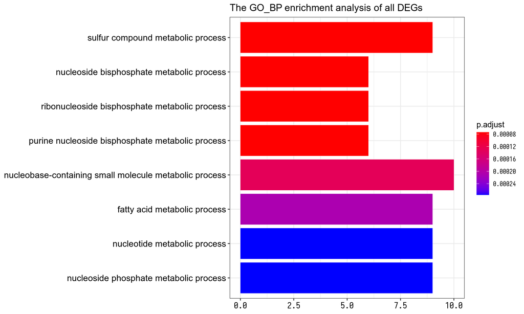

```r
go_bp=enrichGO( gene       = enzyme_info_refine$ensembl_gene_id,
                 OrgDb      = org.Mm.eg.db,
                 keyType    = 'ENSEMBL',
                 ont        = "BP", #'BP','CC','BF'
                 pAdjustMethod = "BH",
                 pvalueCutoff = 0.01,
                 qvalueCutoff = 0.05)

barplot(ego_bp,title="The GO_BP enrichment analysis of all DEGs")
```

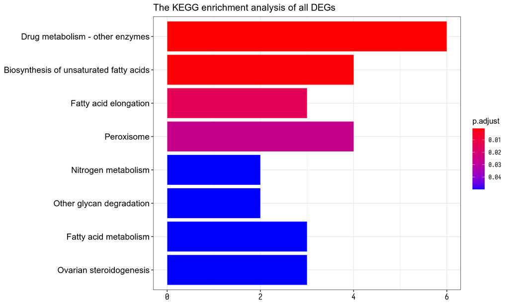

```r
kk=enrichKEGG( gene      =enzyme_info_refine$entrezgene_id,
               organism = 'mmu',
               pvalueCutoff = 0.05)

barplot(kk, title="The KEGG enrichment analysis of all DEGs")
```